# Practical machine learning: Comparisson of methods applied on the exercise measurements data

Vedrana Balicevic

### Problem description (taken from course project description)

Using devices such as Jawbone Up, Nike FuelBand, and Fitbit it is now possible to collect a large amount of data about personal activity relatively inexpensively. These type of devices are part of the quantified self movement - a group of enthusiasts who take measurements about themselves regularly to improve their health, to find patterns in their behavior, or because they are tech geeks. One thing that people regularly do is quantify how much of a particular activity they do, but they rarely quantify how well they do it. In this project, your goal will be to use data from accelerometers on the belt, forearm, arm, and dumbell of 6 participants. They were asked to perform barbell lifts correctly and incorrectly in 5 different ways. More information is available from the website here: http://groupware.les.inf.puc-rio.br/har (see the section on the Weight Lifting Exercise Dataset).

### Data

#### Reading the data

The data for this project was downloaded from the following sources:

```r
trainUrl = "https://d396qusza40orc.cloudfront.net/predmachlearn/pml-training.csv"
testUrl = "https://d396qusza40orc.cloudfront.net/predmachlearn/pml-testing.csv"
```

#### About

obtained with:

- different sensors: accelerometer / gyroscope / magnet
- different direction of measurement: x / y / z / jaw /pitch / roll

Complete list of variables can be obtained with R statements `names(train)` and `str(train)`.

R output is skipped here because the list of variables is too extensive for this report.

#### Data preparation

After examining the variables, we will clean the data in the following way:

1. exclude variables that are not related to the output (person ID, starting time of the excersice, ending time, etc.)
2. exclude variables with NA values - I choose to exclude variables with any occurence of NAs, otherwise I’d also have to impute NAs.
3. exclude variables that have very small variance - the R chunk shows that leftover variables don’t have variance as close to zero as we thought they might, so there is no reason to exclude any one of them.
4. exclude variables that are highly correlated to other variables - we see that some pairs of variables are highly correlated.
5. apply Principal Component Analysis (PCA) which is a good way of rearranging variables and excluding redundant variables (correlated ones).

*Alternatives:*

Also, as I mentioned before, instead of removing all NAs, there is an option of imputing some of them if there are not too many NAs along the column. Here i skip this option cause its either all NAs or none of them per column.

*Important:*

It is also important to remember that all data preprocessing that is done on training data needs to be done on test data as well.

**Mid-results obtained with C and D: List of least variance variables, and cross-correlation table.**

```
##               freqRatio percentUnique zeroVar   nzv
## pitch_belt            1     43.171586   FALSE FALSE
## magnet_belt_x         1      9.954977   FALSE FALSE
## magnet_belt_y         1      9.304652   FALSE FALSE
## gyros_arm_z           1      8.554277   FALSE FALSE
## accel_arm_z           1     27.363682   FALSE FALSE
## magnet_arm_x          1     44.022011   FALSE FALSE
```

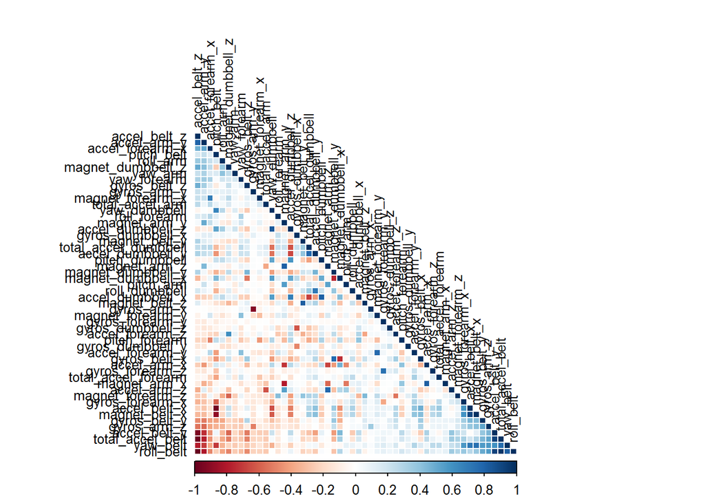

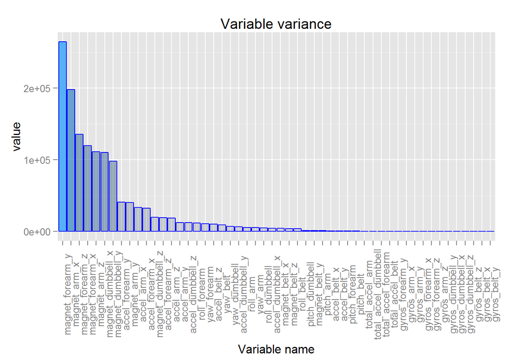

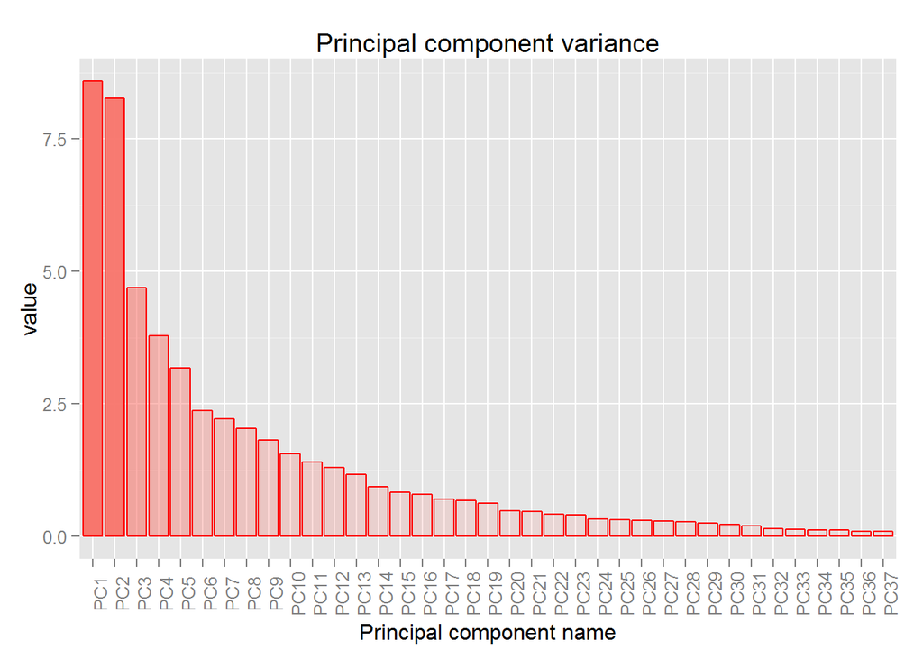

### Data partitioning

Now, important step is to distribute our datasets in the following way:

- TRAINING SET - we separate in into 2 sets:

$\qquad$ – `trainBuild` - for creating the model (with whole dataset or cross-validated, depending on the model).

$\qquad \qquad \qquad \qquad \,$ Error obtained with this is in-sample error.

$\qquad$ – `trainEval` - for evaluating the model. error obtained with this is out-of-sample error.

- TEST SET - we leave it as it is because it’s ONLY for applying the model on the new data, not for evaluating the accuracy of our model

### Building predictors

I decided to try the following predictors on data before PCA and data after PCA:

- Decision tree with and without cross-validation
- Random forest

Each predictor was built with 2 different packages, for practice and for the comparisson. From what I have read, random forest probably does not need cross-validation because of how it internally works.

An example of an obtained tree:

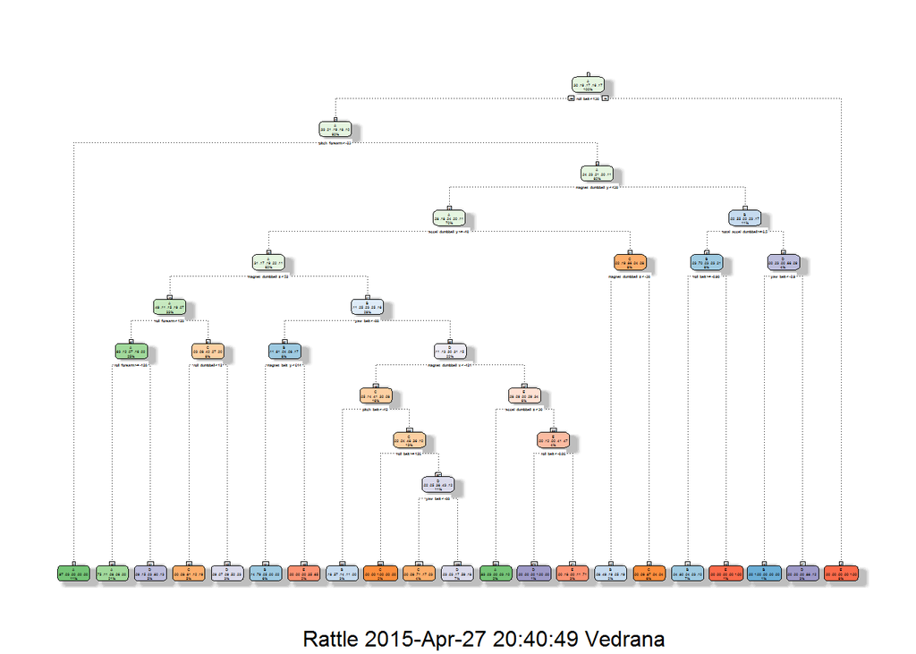

### Results and conclusions

Though i tried to slowly build up the model and compare all models accuracies, a lot of options occured along the way so I had to stop at what I described in this report. Also, the data is too big to wait for so many models to be built.

Here is the table of accuracies (out of sample) of all predictors I built.

CV = cross validation, PP = built-in preprocessing (centering and normalizing), PCA = principal component analysis.

```
##                                 Whole set     CV PP + CV    PCA
## Tree with caret                    0.5361 0.5361  0.5361 0.4639
## Tree with rpart                    0.6988 0.7369     NaN 0.5161
## Random Forest with caret           0.9378    NaN     NaN    NaN
## Random Forest with randomForest    0.9297    NaN     NaN 0.8574
```

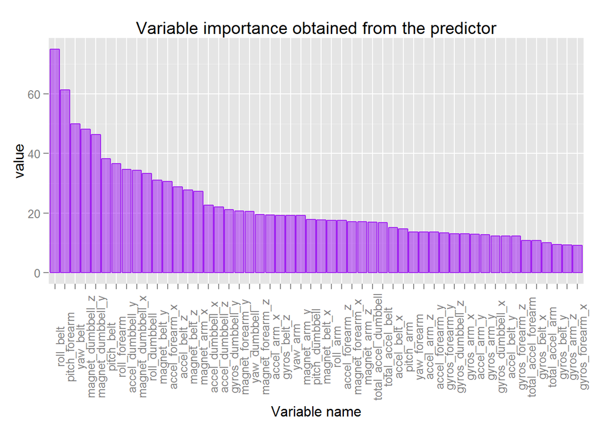

What we can notice from this plot that the variables importance is not necesarily related to variables variance (which is given in the plot before).

#### Test set

I selected the model with the highest accuracy to run it on the test set. To run and submit the results, I used the code provided in the Project description website.

### Note

I reduced the train data size because of the capabilities of my computer (while it can compute these models in normal mode, it gets very slow in markdown mode). From the original 19622 rows I reduced it to 2000 rows, and the best accuracy I obtained was 0.9378, which I’m quite happy with considering the data shrinking. The code is quite extensive because I wanted to do a proper analysis, including the things that were out of the scope of this project.

I prefer to give all code in Appendix, not to interfere with the explanations, and to supress all the (irrelevant) messages that R returns.

### APPENDIX

#### A1. Libraries and seed

```r
# Attaching packages we will need
library(corrplot)
library(caret)
library(rattle)
library(ggplot2)
library(rpart)
library(rpart.plot)
library(party)
library(randomForest)
library(e1071)

# Setting the seed for results reproducibility
set.seed(1212)
```

#### A2. Reading data

```r
trainUrl = "https://d396qusza40orc.cloudfront.net/predmachlearn/pml-training.csv"
testUrl = "https://d396qusza40orc.cloudfront.net/predmachlearn/pml-testing.csv"
```

```r
# Set the working directory
myFolder <- "C:/Users/Vedrana/Desktop/dokumenti/education/The Data Science Specialization/Course 8 - Practical Machine Learning/PML - PA"
setwd(myFolder)

# Check if the files were already downloaded
if (!file.exists("./pml-testing.csv")){
  download.file(trainUrl)
  download.file(testUrl)
  }

# Then read the data
train <- read.csv("pml-training.csv", na.strings=c("NA","#DIV/0!",""))
test  <- read.csv("pml-testing.csv", na.strings=c("NA","#DIV/0!",""))

# Otherwise just read directly from URL without downloading
# train <- read.csv(url(trainUrl));
# test  <- read.csv(url(testUrl));

# Decimate the data cause with so many predictors it gets slow
indTrain <- sample(1:nrow(train), 2000, replace=F)
train    <- train[indTrain,]
```

#### A3. Cleaning data

```r
# A) Index irrelevant variables (non-informative with respect to classes) using LOGICAL indexing
indIDcol <- colSums(is.na(train)) <0
indIDcol[1:7] <- TRUE

# B) Remove NA data. Alternative methods are provided here. Methods B3+B4 were chosen.

# B1: Index only COLUMNS that are COMPLETELY NAs
indNAcol <- colSums(is.na(train)) == nrow(train)

# B2: Method to remove COLUMNS where NA values are over 10% of values
indNAcol <- colSums(is.na(train)) >= 0.1*nrow(train)

# B3: Index COLUMNS with ANY number of NAs
indNAcol <- colSums(is.na(train)) != 0

# B4: Index ROWS that include ANY NAs (that are incomplete)
indNArow <- !complete.cases(train);

# A+B) Remove irrelevant variables and variables with NAs
trainOrig <- train
testOrig  <- test

# Removal of rows (subjects) affects only train data.
# Removal of columns (variables) affects train and test data.
train     <- train[-indNArow,]
train     <- train[,!(indIDcol | indNAcol)]
test      <- test[,!(indIDcol | indNAcol)]

numVariables <- length(names(train))

# C) Calculate variances within variables, order by variance and show only the top several
trainNZV <- nearZeroVar(train, saveMetrics = TRUE)
trainBuildNZV <- trainNZV[with(trainNZV,order(freqRatio)),]
head(trainBuildNZV)

# D) Correlation
corMat <- cor(train[,-numVariables])
corrplot(corMat, order = "FPC", method = "color", type = "lower", tl.cex=0.8, tl.col = rgb(0,0,0))

# E) PCA with caret
preProc  <- preProcess(train[,-numVariables], method = "pca", thresh = 0.99)
trainPCA <- predict(preProc, train[,-numVariables])
testPCA  <- predict(preProc, test[,-numVariables])
trainPCA$classe <- train$classe
```

```r
# Plot the sorted variance contained in original variables and in principal components
varV  <- sapply(train[,-ncol(train)],var)
varP  <- sapply(trainPCA[,-ncol(trainPCA)],var)
dfV <- data.frame(keyName=names(varV), value=varV, row.names=NULL)
dfP <- data.frame(keyName=names(varP), value=varP, row.names=NULL)

g1 <- ggplot() +
  geom_bar(data = dfV, aes (x = reorder(keyName, -value), y=value, alpha = value, fill = value),
           stat = "identity", color = "blue") +
  guides(fill=FALSE,alpha = FALSE) +
  theme(axis.text.x = element_text(angle=90)) +
  labs(title = "Variable variance", x = "Variable name")

g2 <- ggplot() +
  geom_bar(data = dfP, aes (x = reorder(keyName, -value), y=value, alpha = value, fill = "red"),
           stat = "identity", color = "red") +
  guides(fill=FALSE,alpha = FALSE) +
  theme(axis.text.x = element_text(angle=90)) +
  labs(title = "Principal component variance", x = "Principal component name")

print(g1)
print(g2)
```

#### A4. Separating data

```r
# Distribute datasets
inBuild    <- createDataPartition(y = train$classe, p = 0.75, list = FALSE)

trainBuild <- train[inBuild,]
trainEval  <- train[-inBuild,]

trainBuildPCA <- trainPCA[inBuild,]
trainEvalPCA  <- trainPCA[-inBuild,]
```

#### A5. Building tree predictors

```r
## Single tree, but with CV

library(caret)
trainPar = trainControl(method = "cv", number = 4)
rpartPar = rpart.control(cp = 0, xval = 4)

## Train a single decision tree, apply it to the evaluation data

# M1: Using Caret

modFit1      <- train(classe ~ ., data = trainBuild, method = "rpart")
evalPred1    <- predict(modFit1, newdata = trainEval)
ModelInfo1   <- confusionMatrix(data = evalPred1, reference = trainEval$classe)

modFit1CV    <- train(classe ~ ., data = trainBuild, method = "rpart", trControl = trainPar)
evalPred1CV  <- predict(modFit1CV, newdata = trainEval)
ModelInfo1CV <- confusionMatrix(data = evalPred1CV, reference = trainEval$classe)

modFit1CVpca    <- train(classe ~ ., data = trainBuildPCA, method = "rpart", trControl = trainPar)
evalPred1CVpca  <- predict(modFit1CVpca, newdata = trainEvalPCA)
ModelInfo1CVpca <- confusionMatrix(data = evalPred1CVpca, reference = trainEvalPCA$classe)

modFit1PCV    <- train(classe ~ ., data = trainBuild, method = "rpart",
                      preProcess = c("center", "scale"), trControl = trainPar)
evalPred1PCV  <- predict(modFit1PCV, newdata = trainEval)
ModelInfo1PCV <- confusionMatrix(data = evalPred1PCV, reference = trainEval$classe)

# M2: Using rpart

modFit2      <- rpart(classe ~ ., data = trainBuild, method = "class")
evalPred2    <- predict(modFit2, trainEval, type = "class")
ModelInfo2   <- confusionMatrix(data = evalPred2, reference = trainEval$classe)

modFit2CV    <- rpart(classe~., method = "class", data = trainBuild, control = rpartPar)
evalPred2CV  <- predict(modFit2CV, trainEval, type = "class")
ModelInfo2CV <- confusionMatrix(data = evalPred2CV, reference = trainEval$classe)

modFit2PCA   <- rpart(classe ~ ., data = trainBuildPCA, method = "class")
evalPred2PCA <- predict(modFit2PCA, trainEvalPCA, type = "class")
ModelInfo2PCA<- confusionMatrix(data = evalPred2PCA, reference = trainEval$classe)
```

```r
# Plot the tree
fancyRpartPlot(modFit2)
```

#### A5. Building random forest predictors

```r
## Train a random forest, apply it to the evaluation data

# M3: Train random forest with caret package

modFit3      <- train(classe~ ., data = trainBuild, method = "rf", prox = TRUE)
evalPred3    <- predict(modFit3, newdata = trainEval)
ModelInfo3   <- confusionMatrix(data = evalPred3, reference = trainEval$classe)

# M4: Train random forest with randomforest package
modFit4      <- randomForest(classe ~. , data = trainBuild)
evalPred4    <- predict(modFit4, newdata = trainEval, type = "class")
ModelInfo4   <- confusionMatrix(data = evalPred4, reference = trainEval$classe)

modFit4PCA      <- randomForest(classe ~. , data = trainBuildPCA)
evalPred4PCA    <- predict(modFit4PCA, newdata = trainEvalPCA, type = "class")
ModelInfo4PCA   <- confusionMatrix(data = evalPred4PCA, reference = trainEval$classe)
```

#### A6. Combine the results into accuracy table

```r
# Put accuracy values for all models in a single data.frame for a table-like display of results:
accuracyTable <- data.frame(rbind(
                      cbind(ModelInfo1$overall[1], ModelInfo1CV$overall[1], ModelInfo1PCV$overall[1], ModelInfo1CVpca$overall[1]),
                      cbind(ModelInfo2$overall[1], ModelInfo2CV$overall[1], NaN, ModelInfo2PCA$overall[1]),
                      cbind(ModelInfo3$overall[1], NaN, NaN, NaN),
                      cbind(ModelInfo4$overall[1], NaN, NaN, ModelInfo4PCA$overall[1])))
rownames(accuracyTable) <- c("Tree with caret", "Tree with rpart",
                       "Random Forest with caret", "Random Forest with randomForest")
colnames(accuracyTable) <- c("Whole set", "CV", "PP + CV", "PCA")
```

#### A7. Variable importance plot from the predictor

```r
# Importance plot
imp4 <- modFit4$importance[,1]
df4  <- data.frame(keyName=names(imp4), value=imp4, row.names=NULL)
g3   <- ggplot() +
    geom_bar(data = df4, aes (x = reorder(keyName, -value), y=value, alpha = 0.3),
             stat = "identity", color = "purple", fill = "purple") +
    guides(fill=FALSE,alpha = FALSE) +
    theme(axis.text.x = element_text(angle=90)) +
    labs(title = "Variable importance obtained from the predictor", x = "Variable name")
print(g3)
```

#### A8. Test set prediction

```r
finalModel <- modFit3
pml_write_files = function(x){
  n = length(x)
  for(i in 1:n){
    filename = paste0("problem_id_",i,".txt")
    write.table(x[i],file=filename,quote=FALSE,row.names=FALSE,col.names=FALSE)
  }
}

testPrediction <- predict(finalModel, newdata = test)
pml_write_files(testPrediction)
```